# Home Work Assignment - 04

Critical Thinking Group 5

# 1 Overview

The data set contains approximately 8161 records. Each record represents a customer profile at an auto insurance company. Each record has two response variables.  
The first response variable, TARGET_FLAG, is a 1 or a 0. A “1” means that the person was in a car crash. A zero means that the person was not in a car crash.  
The second response variable is TARGET_AMT. This is the amount spent on repairs if there was a crash. This value is zero if the person did not crash their car. But if they did crash their car, this number will be a value greater than zero.  
We will be exploring, analyzing, and modeling the training data. Since there are 2 different predictions we have to work with, we will deal with each prediction independently. The following are the 2 predictions we will be modeling for:  
1. TARGET_FLAG - This dependent variable tells whether there was a crash or not. This is a binary variable and as such we will be using a Logistic Regression Model to predict this.  
2. TARGET_AMT - This dependent variable gives the amount / cost of repairs if there was a crash. This is a continuous variable and we will ve using a Linear Regression Model to predict this.  
Each of the above models will be built and evaluated separately. In the first section of this document we will deal with the Logistic Model for TARGET_FLAG and in the second section we will deal with Linear Model for the TARGET_AMT  
Out of the many models for each task, we will go ahead and shortlist one model that works the best. We will then use these models (one for each task) on the test / evaluation data.  
To attain our objective, we will be follow the below steps for each modeling exercise:  
1 -Data Exploration  
2 -Data Preparation  
3 -Build Models  
4 -Select Models  
**Model Selection Strategy:** As a strategy, we will split the train dataset into 2 parts - TRAIN and VALID. In the VALID dataset, we will hold out some values to validate how well the model is trained using the TRAIN dataset. We will then use the Model that performs the best on the EVALUATION data to give the required output. We will split the TRAIN / VALID data after the **Data Exploration / Preparation** before the **Build Models**.  
**Please Note:**  
- While working on the Linear Models for the TARGET_AMT, we will be using only a subset of the data where the TARGET_FLAG = 1. This will give us all the records where there was a crash and subsequently a repair amount.  
- While Predicting the TARGET_AMT with the given Evaluation dataset, We will do 2 evaluations:  
1. Independent Prediction - Here we use the Evaluation dataset variables to predict the TARGET_AMT without the need to predict the TARGET_FLAG since the model has been developed independently.  
2. Dependent Prediction - Here we will take the output of the TARGET_FLAG predictions on the Evaluation dataset and use only those rows that were classified as a “Crash” and use it as the input to the TARGET_AMT prediction. So this is a two step prediction, one for the TARGET_FLAG and using the output to predict TARGET_AMT.

# 2 Logistic Regression for TARGET_FLAG

In this section we will use Logistic regression to model the TARGET_FLAG. We will first start with the Data Exploration.

## 2.1 Data Exploration Analysis

In this sub-section we will explore and gain some insights into the dataset by pursuing the below high level steps and inquiries:  
-Variable Identification / Relationships  
-Data Summary Analysis  
-Missing Values  
-Outliers identification -Analysis the link function

### 2.1.1 Variable Identification

First let’s display and examine the data dictionary or the data columns as shown in table 1

Variable Description

[output not shown]

```
## 'data.frame':    8161 obs. of  26 variables:
##  $ INDEX      : int  1 2 4 5 6 7 8 11 12 13 ...
##  $ TARGET_FLAG: int  0 0 0 0 0 1 0 1 1 0 ...
##  $ TARGET_AMT : num  0 0 0 0 0 ...
##  $ KIDSDRIV   : int  0 0 0 0 0 0 0 1 0 0 ...
##  $ AGE        : int  60 43 35 51 50 34 54 37 34 50 ...
##  $ HOMEKIDS   : int  0 0 1 0 0 1 0 2 0 0 ...
##  $ YOJ        : int  11 11 10 14 NA 12 NA NA 10 7 ...
##  $ INCOME     : Factor w/ 6613 levels "","$0","$1,007",..: 5033 6292 1250 1 509 746 1488 315 4765 282 ...
##  $ PARENT1    : Factor w/ 2 levels "No","Yes": 1 1 1 1 1 2 1 1 1 1 ...
##  $ HOME_VAL   : Factor w/ 5107 levels "","$0","$100,093",..: 2 3259 348 3917 3034 2 1 4167 2 2 ...
##  $ MSTATUS    : Factor w/ 2 levels "Yes","z_No": 2 2 1 1 1 2 1 1 2 2 ...
##  $ SEX        : Factor w/ 2 levels "M","z_F": 1 1 2 1 2 2 2 1 2 1 ...
##  $ EDUCATION  : Factor w/ 5 levels "<High School",..: 4 5 5 1 4 2 1 2 2 2 ...
##  $ JOB        : Factor w/ 9 levels "","Clerical",..: 7 9 2 9 3 9 9 9 2 7 ...
##  $ TRAVTIME   : int  14 22 5 32 36 46 33 44 34 48 ...
##  $ CAR_USE    : Factor w/ 2 levels "Commercial","Private": 2 1 2 2 2 1 2 1 2 1 ...
##  $ BLUEBOOK   : Factor w/ 2789 levels "$1,500","$1,520",..: 434 503 2212 553 802 746 2672 701 135 852 ...
##  $ TIF        : int  11 1 4 7 1 1 1 1 1 7 ...
##  $ CAR_TYPE   : Factor w/ 6 levels "Minivan","Panel Truck",..: 1 1 6 1 6 4 6 5 6 5 ...
##  $ RED_CAR    : Factor w/ 2 levels "no","yes": 2 2 1 2 1 1 1 2 1 1 ...
##  $ OLDCLAIM   : Factor w/ 2857 levels "$0","$1,000",..: 1449 1 1311 1 432 1 1 510 1 1 ...
##  $ CLM_FREQ   : int  2 0 2 0 2 0 0 1 0 0 ...
##  $ REVOKED    : Factor w/ 2 levels "No","Yes": 1 1 1 1 2 1 1 2 1 1 ...
##  $ MVR_PTS    : int  3 0 3 0 3 0 0 10 0 1 ...
##  $ CAR_AGE    : int  18 1 10 6 17 7 1 7 1 17 ...
##  $ URBANICITY : Factor w/ 2 levels "Highly Urban/ Urban",..: 1 1 1 1 1 1 1 1 1 2 ...
```

```
## [1] "Yes"  "z_No"
```

```
## [1] "M"   "z_F"
```

```
## [1] "<High School"  "Bachelors"     "Masters"       "PhD"
## [5] "z_High School"
```

```
## [1] ""              "Clerical"      "Doctor"        "Home Maker"
## [5] "Lawyer"        "Manager"       "Professional"  "Student"
## [9] "z_Blue Collar"
```

```
## [1] "Minivan"     "Panel Truck" "Pickup"      "Sports Car"  "Van"
## [6] "z_SUV"
```

```
## [1] "Highly Urban/ Urban"   "z_Highly Rural/ Rural"
```

```
## [1] "No"  "Yes"
```

From the output above we can make the following observations:  
- some numeric variables like INCOME, HOME_VAL, BLUEBOOK, OLDCLAIM have been converted to Factor variables. This needs to be set right.  
- Some of the variables like MSTATUS, SEX, EDUCATION, JOB, CAR_TYPE, URBANICITY have some of the values encoded with “z_”. Not that this will impact the analysis, but it will look a bit odd. So we will be fixing this.  
- EDUCATION has 2 “High School” values - one starting with “<” and another starting with “z_”. It is assumed that both these values are to be converted to “HIGH School”.  
- JOB has a “” value. This needs to be replaced with NA.  
- We will also create dummy variables for all the factors.  
- Please note that we will not be using INDEX variable as it serves as just an identifier for each row. And has no relationships to other variables.  
Making the above fixes to the data, we now have a “clean” dataset which can be explored further.

```
##   TARGET_FLAG       TARGET_AMT        KIDSDRIV           AGE
##  Min.   :0.0000   Min.   :     0   Min.   :0.0000   Min.   :16.00
##  1st Qu.:0.0000   1st Qu.:     0   1st Qu.:0.0000   1st Qu.:39.00
##  Median :0.0000   Median :     0   Median :0.0000   Median :45.00
##  Mean   :0.2638   Mean   :  1504   Mean   :0.1711   Mean   :44.79
##  3rd Qu.:1.0000   3rd Qu.:  1036   3rd Qu.:0.0000   3rd Qu.:51.00
##  Max.   :1.0000   Max.   :107586   Max.   :4.0000   Max.   :81.00
##                                                     NA's   :6
##     HOMEKIDS           YOJ           INCOME        HOME_VAL
##  Min.   :0.0000   Min.   : 0.0   Min.   :   1   Min.   :   1
##  1st Qu.:0.0000   1st Qu.: 9.0   1st Qu.: 926   1st Qu.:   2
##  Median :0.0000   Median :11.0   Median :2817   Median :1245
##  Mean   :0.7212   Mean   :10.5   Mean   :2876   Mean   :1685
##  3rd Qu.:1.0000   3rd Qu.:13.0   3rd Qu.:4701   3rd Qu.:3164
##  Max.   :5.0000   Max.   :23.0   Max.   :6613   Max.   :5107
##                   NA's   :454
##     TRAVTIME         BLUEBOOK         TIF            OLDCLAIM
##  Min.   :  5.00   Min.   :   1   Min.   : 1.000   Min.   :   1.0
##  1st Qu.: 22.00   1st Qu.: 478   1st Qu.: 1.000   1st Qu.:   1.0
##  Median : 33.00   Median :1124   Median : 4.000   Median :   1.0
##  Mean   : 33.49   Mean   :1284   Mean   : 5.351   Mean   : 552.3
##  3rd Qu.: 44.00   3rd Qu.:2234   3rd Qu.: 7.000   3rd Qu.:1015.0
##  Max.   :142.00   Max.   :2789   Max.   :25.000   Max.   :2857.0
##
##     CLM_FREQ         MVR_PTS          CAR_AGE         PARENT1_No
##  Min.   :0.0000   Min.   : 0.000   Min.   :-3.000   Min.   :0.000
##  1st Qu.:0.0000   1st Qu.: 0.000   1st Qu.: 1.000   1st Qu.:1.000
##  Median :0.0000   Median : 1.000   Median : 8.000   Median :1.000
##  Mean   :0.7986   Mean   : 1.696   Mean   : 8.328   Mean   :0.868
##  3rd Qu.:2.0000   3rd Qu.: 3.000   3rd Qu.:12.000   3rd Qu.:1.000
##  Max.   :5.0000   Max.   :13.000   Max.   :28.000   Max.   :1.000
##                                    NA's   :510
##   PARENT1_Yes      MSTATUS_No      MSTATUS_Yes         SEX_F
##  Min.   :0.000   Min.   :0.0000   Min.   :0.0000   Min.   :0.0000
##  1st Qu.:0.000   1st Qu.:0.0000   1st Qu.:0.0000   1st Qu.:0.0000
##  Median :0.000   Median :0.0000   Median :1.0000   Median :1.0000
##  Mean   :0.132   Mean   :0.4003   Mean   :0.5997   Mean   :0.5361
##  3rd Qu.:0.000   3rd Qu.:1.0000   3rd Qu.:1.0000   3rd Qu.:1.0000
##  Max.   :1.000   Max.   :1.0000   Max.   :1.0000   Max.   :1.0000
##
```

[output cut: 49 more lines]

```
##  Min.   :0.0000   Min.   :0.0000   Min.   :0.0000
##  1st Qu.:0.0000   1st Qu.:1.0000   1st Qu.:0.0000
##  Median :0.0000   Median :1.0000   Median :0.0000
##  Mean   :0.2914   Mean   :0.8775   Mean   :0.1225
##  3rd Qu.:1.0000   3rd Qu.:1.0000   3rd Qu.:0.0000
##  Max.   :1.0000   Max.   :1.0000   Max.   :1.0000
##
##  URBANICITY_Highly.Rural..Rural URBANICITY_Highly.Urban..Urban
##  Min.   :0.0000                 Min.   :0.0000
##  1st Qu.:0.0000                 1st Qu.:1.0000
##  Median :0.0000                 Median :1.0000
##  Mean   :0.2045                 Mean   :0.7955
##  3rd Qu.:0.0000                 3rd Qu.:1.0000
##  Max.   :1.0000                 Max.   :1.0000
##
```

Since we are doing a Logistic Regression for TARGET_FLAG we need to check for the following assumptions:  
– The dependent variable need not to be normally distributed  
– Errors need to be independent but not normally distributed.  
– We will be using GLM and GLM does not assume a linear relationship between dependent and independent variables. However, it assumes a linear relationship between link function and independent variables in logit model.  
– Also does not use OLS (Ordinary Least Square) for parameter estimation. Instead, it uses maximum likelihood estimation (MLE)

### 2.1.2 Data Summary and Correlation Analysis

In this section, we will create summary data to better understand the relationship each of the variables have with our dependent variables using correlation, central tendency, and dispersion as shown below:

Now we will produce the correlation table between the independent variables and the dependent variable - TARGET_FLAG

Correlation between TARGET_FLAG and predictor variables

|  | Correlation_TARGET_FLAG |
| --- | --- |
| TARGET_FLAG | 1.0000000 |
| TARGET_AMT | 0.5342461 |
| URBANICITY_Highly.Urban..Urban | 0.2242509 |
| MVR_PTS | 0.2191971 |
| CLM_FREQ | 0.2161961 |
| OLDCLAIM | 0.1902875 |
| PARENT1_Yes | 0.1576222 |
| REVOKED_Yes | 0.1519391 |
| CAR_USE_Commercial | 0.1426737 |
| EDUCATION_High.School | 0.1380116 |
| MSTATUS_No | 0.1351248 |
| HOMEKIDS | 0.1156210 |
| JOB_Blue.Collar | 0.1057869 |
| KIDSDRIV | 0.1036683 |
| JOB_Student | 0.0795874 |
| CAR_TYPE_Sports.Car | 0.0572528 |
| CAR_TYPE_Pickup | 0.0566433 |
| BLUEBOOK | 0.0504453 |
| TRAVTIME | 0.0483683 |
| CAR_TYPE_SUV | 0.0450322 |
| JOB_Clerical | 0.0280954 |
| SEX_F | 0.0210786 |
| JOB_Home.Maker | 0.0114210 |
| RED_CAR_no | 0.0069473 |
| CAR_TYPE_Van | 0.0030204 |
| CAR_TYPE_Panel.Truck | -0.0003424 |
| RED_CAR_yes | -0.0069473 |
| SEX_M | -0.0210786 |
| INCOME | -0.0338365 |
| JOB_Professional | -0.0404212 |
| EDUCATION_Bachelors | -0.0426526 |
| JOB_Doctor | -0.0605425 |
| JOB_Lawyer | -0.0643342 |
| EDUCATION_PhD | -0.0654121 |
| YOJ | -0.0705118 |
| EDUCATION_Masters | -0.0762960 |
| TIF | -0.0823700 |
| CAR_AGE | -0.1006506 |
| AGE | -0.1032167 |
| JOB_Manager | -0.1097548 |
| MSTATUS_Yes | -0.1351248 |
| CAR_TYPE_Minivan | -0.1369991 |
| CAR_USE_Private | -0.1426737 |
| HOME_VAL | -0.1485715 |
| REVOKED_No | -0.1519391 |
| PARENT1_No | -0.1576222 |
| URBANICITY_Highly.Rural..Rural | -0.2242509 |

The above table suggests that none of the variables seem to have a very strong correlation with TARGET_FLAG. However, CAR_TYPE_Van, RED_CAR_no, JOB_Home.Maker, SEX_F, JOB_Clerical, CAR_TYPE_SUV, TRAVTIME, BLUEBOOK, CAR_TYPE_Pickup, CAR_TYPE_Sports.Car, JOB_Student, KIDSDRIV, JOB_Blue.Collar, HOMEKIDS, MSTATUS_No, EDUCATION_High.School, CAR_USE_Commercial, REVOKED_Yes, PARENT1_Yes, OLDCLAIM, CLM_FREQ, MVR_PTS and URBANICITY_Highly.Urban..Urban have a positive correlation.  
Similarly, URBANICITY_Highly.Rural..Rural, PARENT1_No, REVOKED_No, HOME_VAL, CAR_USE_Private, CAR_TYPE_Minivan, MSTATUS_Yes, JOB_Manager, AGE, CAR_AGE, TIF, EDUCATION_Masters, YOJ, EDUCATION_PhD, JOB_Lawyer, JOB_Doctor, EDUCATION_Bachelors, JOB_Professional, INCOME, SEX_M, RED_CAR_yes, CAR_TYPE_Panel.Truck have a negative correlation.  
Lets now see how values in some of the variable affects the correlation:  
CAR_TYPE - If you drive Minivans and Panel Trucks you have lesser chance of being in a crash as against Pickups, Sports, SUVs and Vans. Since the distiction is clear, we believe that binning this variable accordingly will help strengthen the correlation.  
EDUCATION - If you have only a high school education then you are more likely to crash than if you have a Bachelors, Masters or a Phd. Again binning this variable will strengthen the correlation.  
JOB - If you are a Student, Homemaker, or in a Blue Collar or Clerical job, you are more likely to be in a crash against Doctor, Lawyer, Manager or professional. Again binning this variable will strengthen the correlation.  
We will carry out the above transformations in the Data Preparation phase.

### 2.1.3 Missing Values

Based on the missing data from the below table, we can see that there are a few missing values for AGE, CAR_AGE, YOJ and JOB variables.  
Table: Missing Values

|  | missings |
| --- | --- |
| TARGET_FLAG | 0 |
| TARGET_AMT | 0 |
| KIDSDRIV | 0 |
| AGE | 6 |
| HOMEKIDS | 0 |
| YOJ | 454 |
| INCOME | 0 |
| HOME_VAL | 0 |
| TRAVTIME | 0 |
| BLUEBOOK | 0 |
| TIF | 0 |
| OLDCLAIM | 0 |
| CLM_FREQ | 0 |
| MVR_PTS | 0 |
| CAR_AGE | 510 |
| PARENT1_No | 0 |
| PARENT1_Yes | 0 |
| MSTATUS_No | 0 |
| MSTATUS_Yes | 0 |
| SEX_F | 0 |
| SEX_M | 0 |
| EDUCATION_Bachelors | 0 |
| EDUCATION_High.School | 0 |
| EDUCATION_Masters | 0 |
| EDUCATION_PhD | 0 |
| JOB_Blue.Collar | 526 |
| JOB_Clerical | 526 |
| JOB_Doctor | 526 |
| JOB_Home.Maker | 526 |
| JOB_Lawyer | 526 |
| JOB_Manager | 526 |
| JOB_Professional | 526 |
| JOB_Student | 526 |
| CAR_USE_Commercial | 0 |
| CAR_USE_Private | 0 |
| CAR_TYPE_Minivan | 0 |
| CAR_TYPE_Panel.Truck | 0 |
| CAR_TYPE_Pickup | 0 |
| CAR_TYPE_Sports.Car | 0 |
| CAR_TYPE_SUV | 0 |
| CAR_TYPE_Van | 0 |
| RED_CAR_no | 0 |
| RED_CAR_yes | 0 |
| REVOKED_No | 0 |
| REVOKED_Yes | 0 |
| URBANICITY_Highly.Rural..Rural | 0 |
| URBANICITY_Highly.Urban..Urban | 0 |

We can try and impute values to AGE, YOJ, CAR_AGE. However, we will not be able to impute values for JOB since this is a categorical variable. Though there are a few methods to do this imputation, it may not be worth it.

Lets see the impact if we have to exclude these missing records.

```
## [1] 1407
```

```
## [1] 17.24053
```

We see from the above that excluding the missing rows will remove about 17.24% of the records. This would not seem to have too much of an impact. We will exclude the rows with the missing values when we do the data preparation / tranformations for the TARGET_FLAG dataset.

### 2.1.4 Outliers identification

In this sub-section, we will look at the boxplots and determine the outliers in variables and decide on whether to act on the outliers. We will do the outliers only on the numeric variables. Below are the plots:

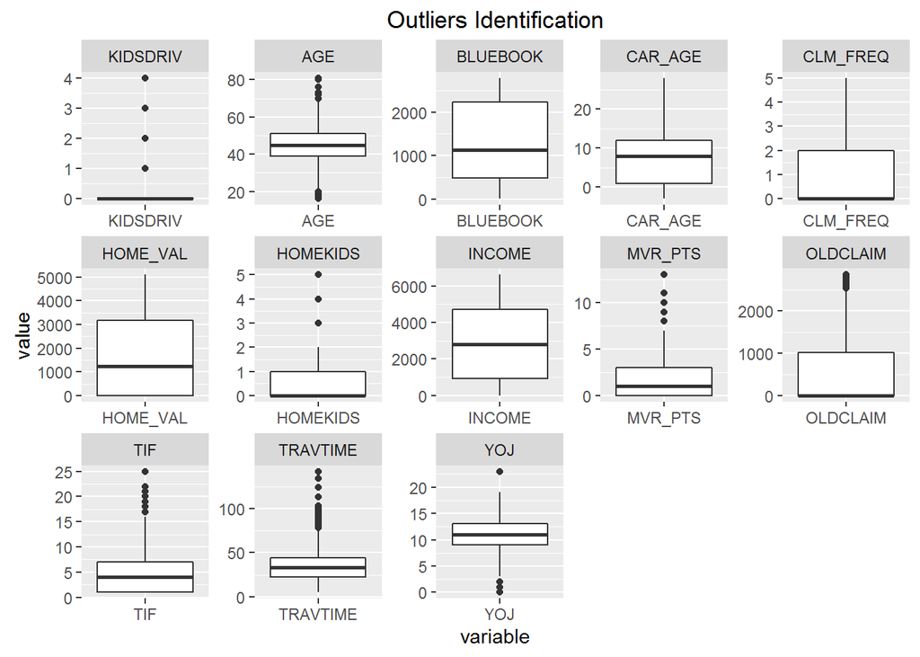

From the “Outliers identification” plot above, we see that we have few outliers that we need to treat. We see that: KIDSDRIV, AGE, HOMEKIDS, MVR_PTS, OLDCLAIM, TIF, TRAVTIME, YOJ need to be treated when we do the data preparation for modeling the TARGET_FLAG.

### 2.1.5 Analysis the link function

In this section, we will investigate how our initial data aligns with a typical logistic model plot.

Recall the Logistic Regression is part of a larger class of algorithms known as Generalized Linear Model (glm). The fundamental equation of generalized linear model is:

$g(E(y)) = a+ Bx_1+B_2x_2+ B_3x_3+...$

where, g() is the link function, E(y) is the expectation of target variable and $B_0 + B_1x_1 + B_2x_2+B_3x_3$ is the linear predictor ( $B_0,B_1,B_2, B_3$ to be predicted). The role of link function is to ‘link’ the expectation of y to linear predictor.

In logistic regression, we are only concerned about the probability of outcome dependent variable ( success or failure). As described above, g() is the link function. This function is established using two things: Probability of Success (p) and Probability of Failure (1-p). p should meet following criteria: It must always be positive (since p >= 0) It must always be less than equals to 1 (since p <= 1).

Now let’s investigate how our initial data model aligns with the above criteria. In other words, we will plot regression model plots for each variable and compare it to a typical logistic model plot:

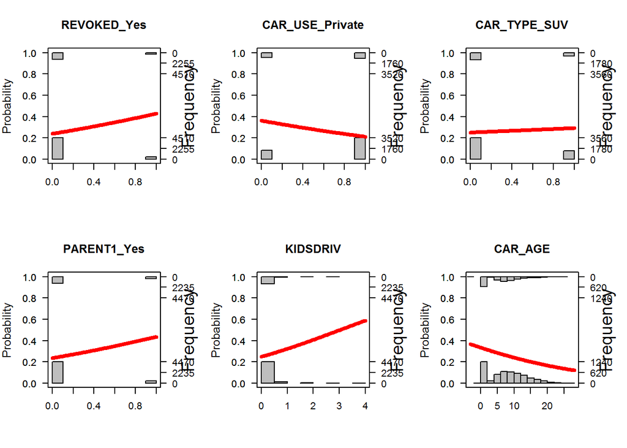

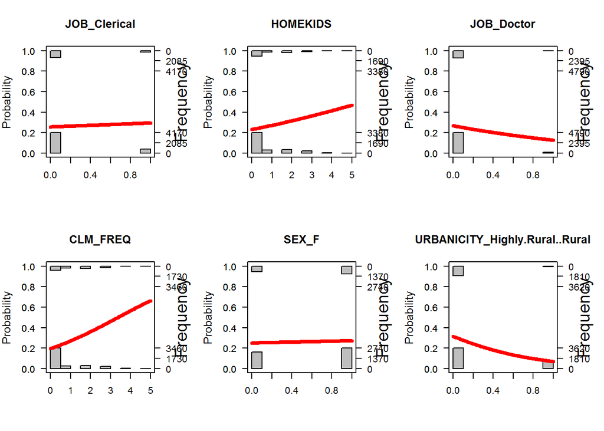

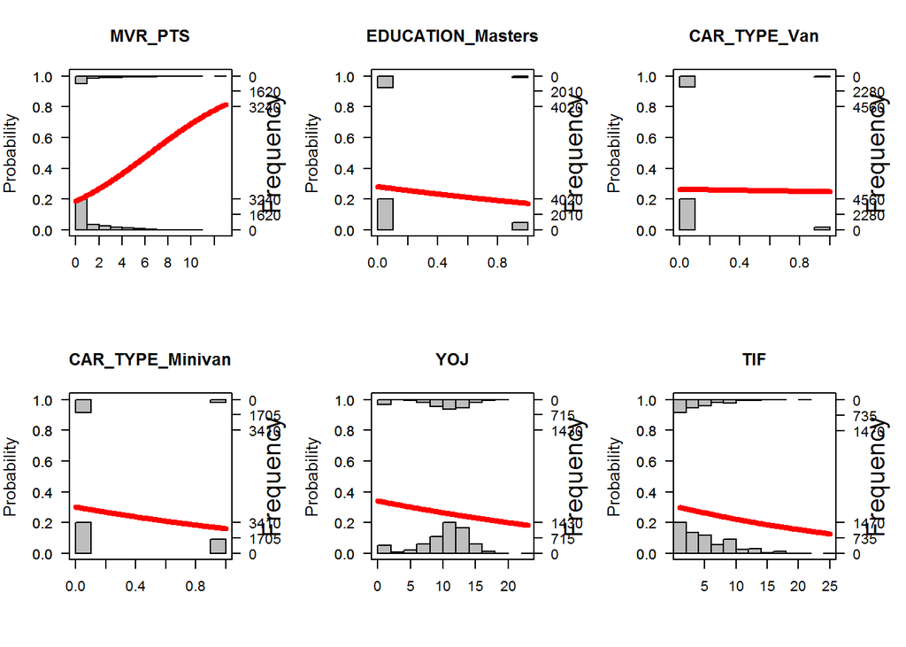

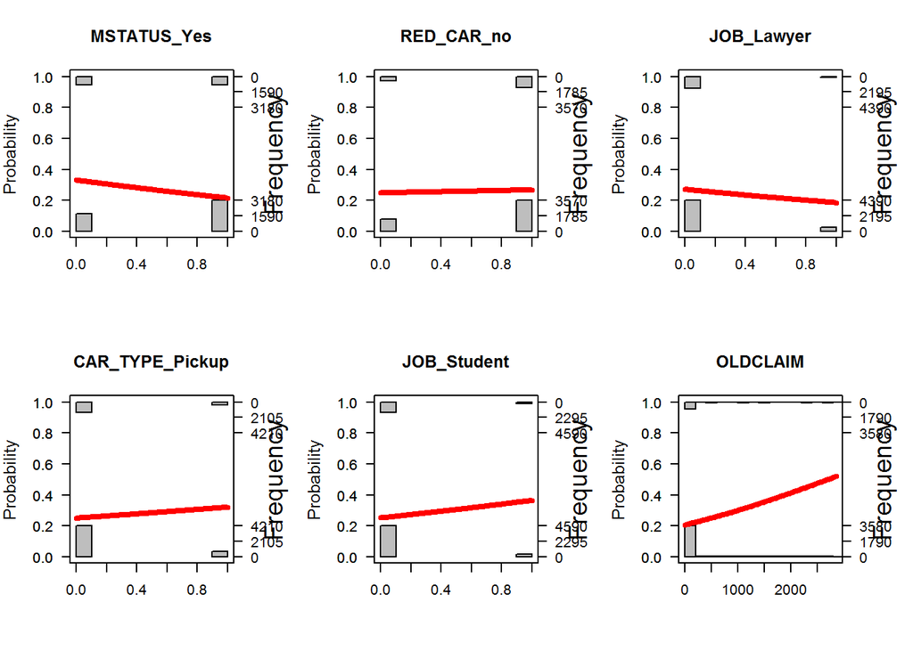

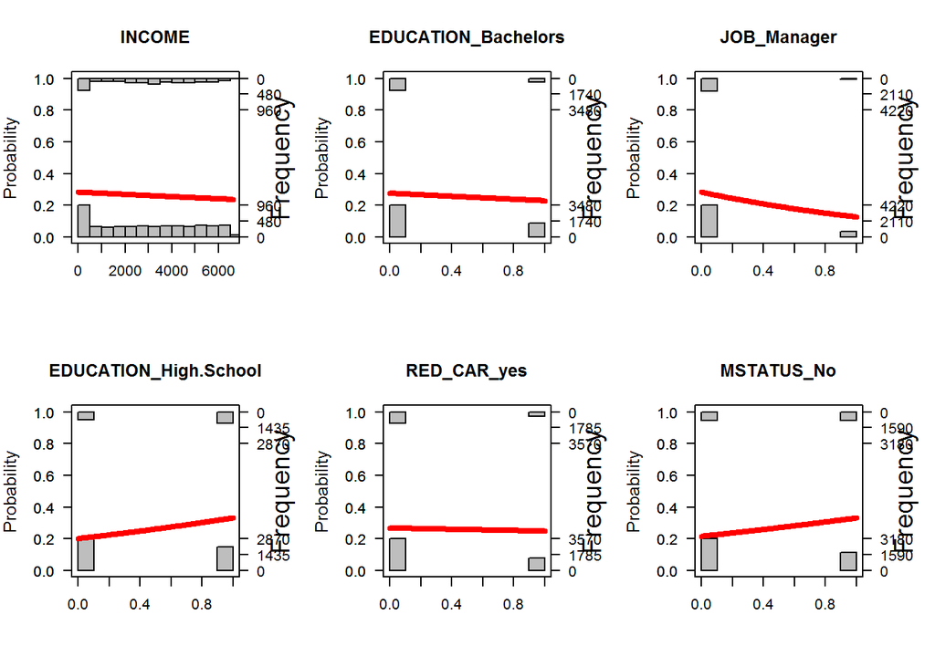

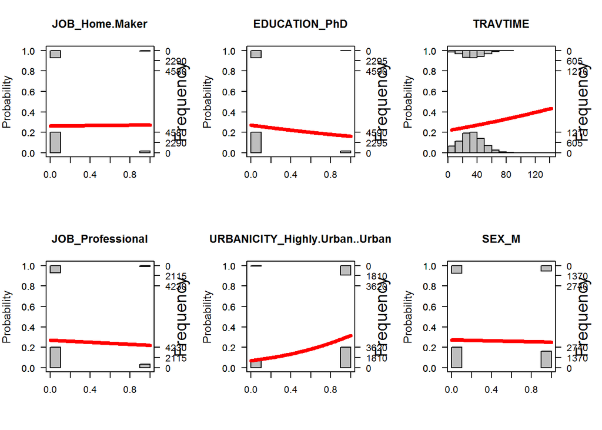

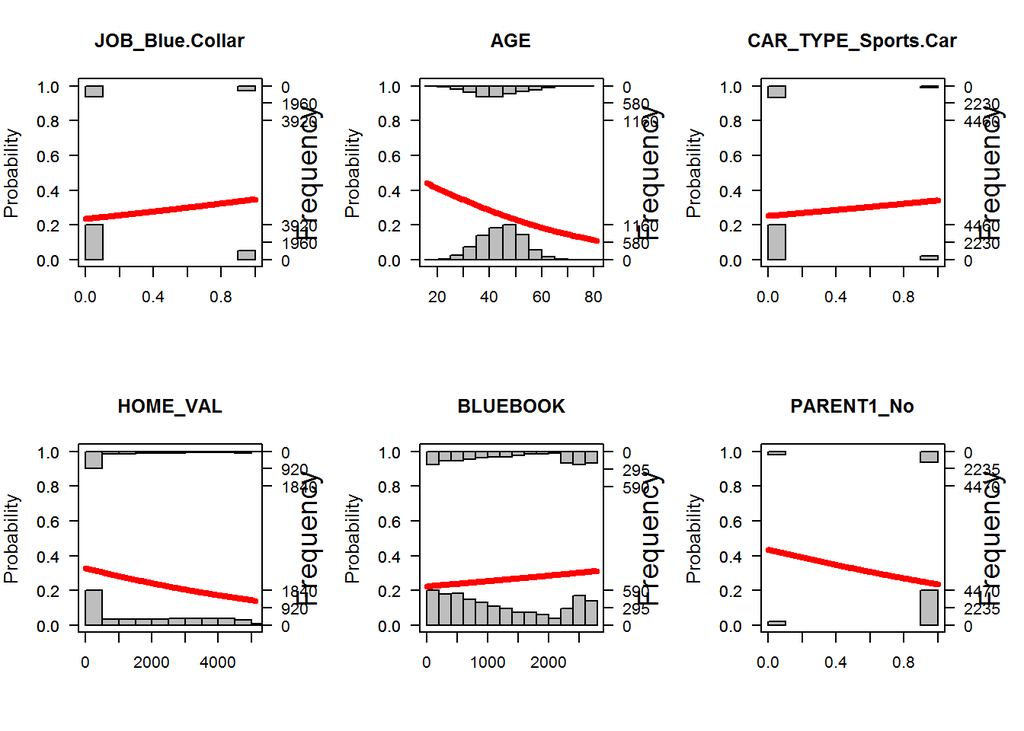

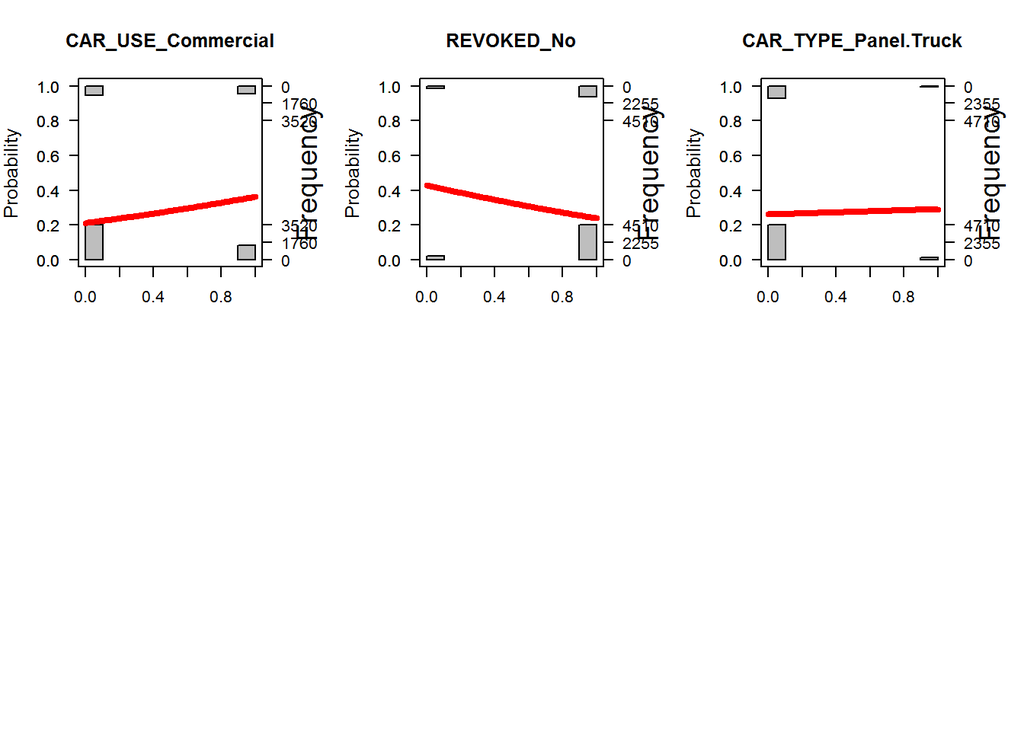

## 2.2 Data Preparation

Now that we have completed the data exploration / analysis, we will be transforming the data for use in analysis and modeling.  
We will be following the below steps as guidelines:  
- Outliers treatment  
- Missing values treatment  
- Adding New Variables

### 2.2.1 Outliers treatment

In this sub-section, we will check different transformations for each of the variables - KIDSDRIV, AGE, HOMEKIDS, MVR_PTS, OLDCLAIM, TIF, TRAVTIME and YOJ - and create the appropriate outlier-handled / transformed variables.

**Transformations for KIDSDRV**

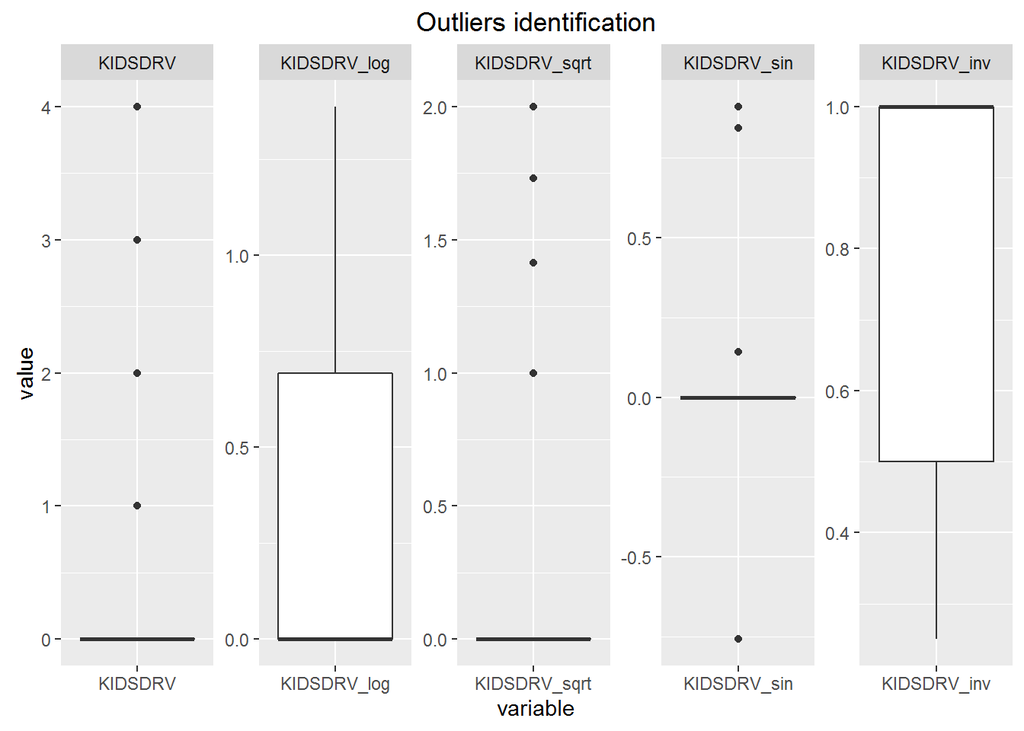

From the above charts we can see that a log or an inverse transformation works well for KIDSDRV. Hence, We create both these variables.

**Transformations for AGE**

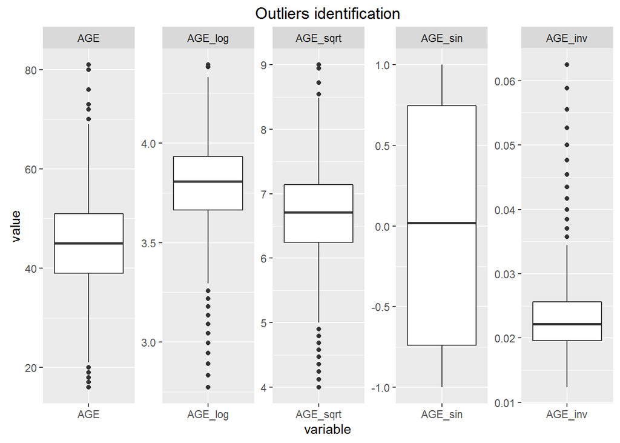

From the above charts we can see that a sin transformation works well for AGE. We will create this variable.

**Transformations for HOMEKIDS**

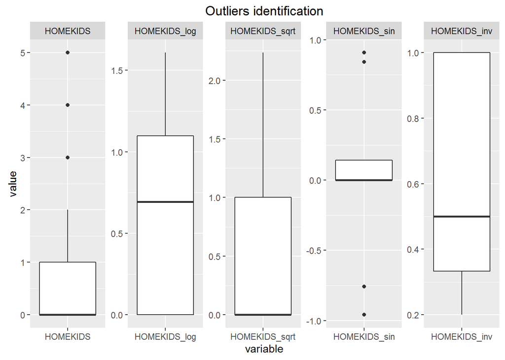

**Transformations for MVR_PTS**

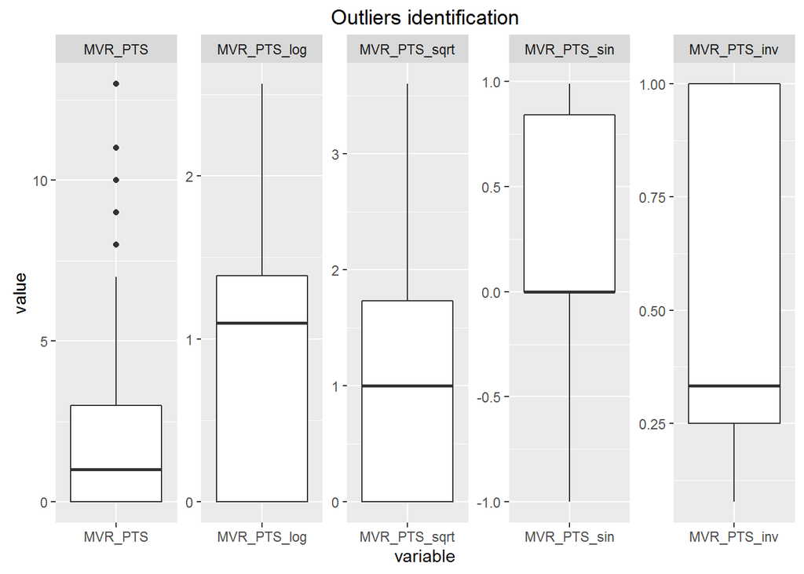

From the above charts we can see that a log, sqrt or an inverse transformation works better for MVR_PTS. Hence, We will create these variables.

**Transformations for OLDCLAIM**

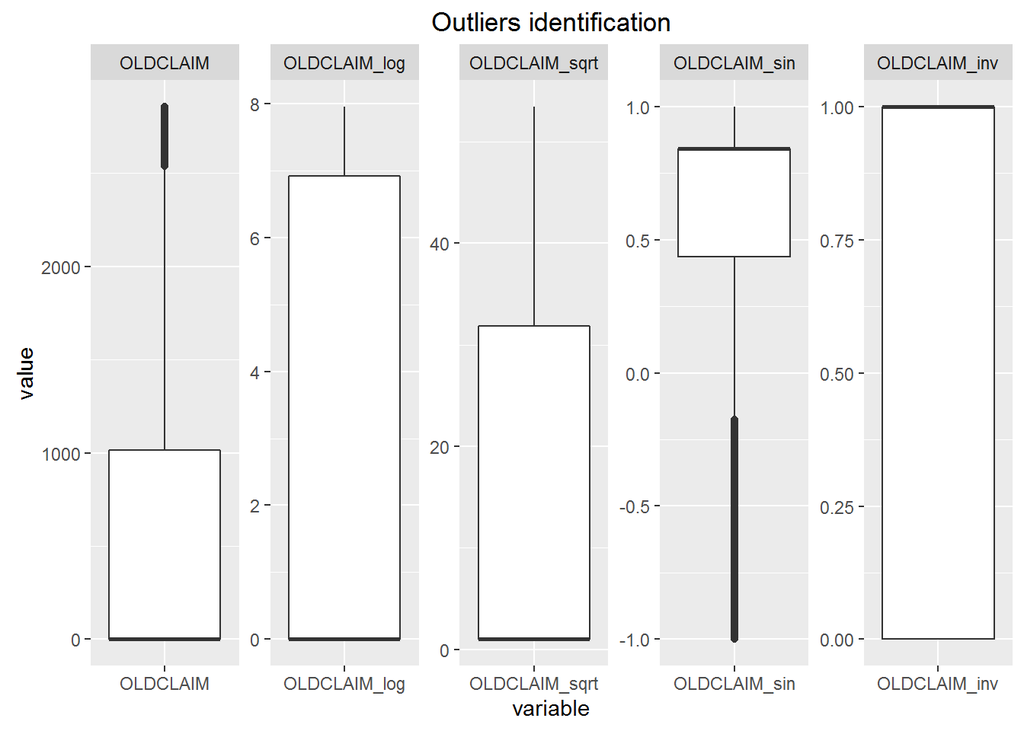

From the above charts we can see that a log, sqrt or an inverse transformation works better for OLDCLAIM. Hence, We will create these variables.

**Transformations for TIF**

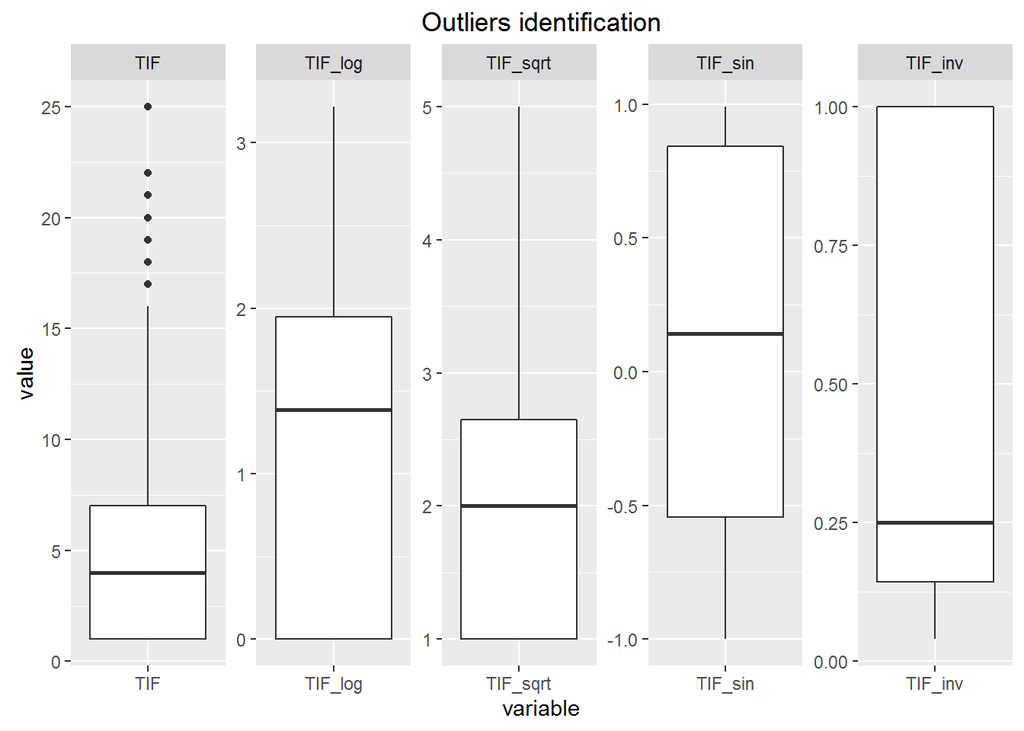

From the above charts we can see that a log, sqrt, sin or an inverse transformation works well for TIF. Hence, We will create these variables.

**Transformations for TRAVTIME**

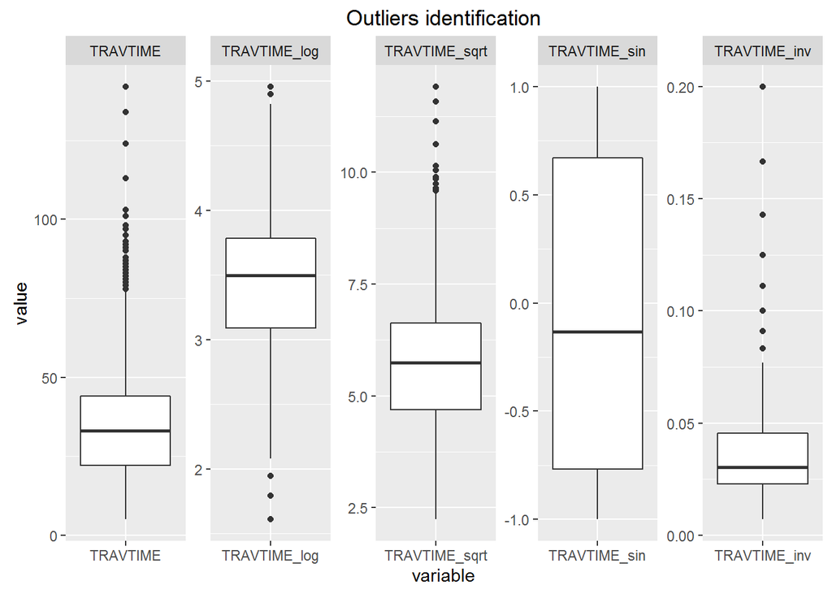

From the above charts we can see that a sin transformation works well for TRAVTIME. Hence, We will create this variable.

**Transformations for YOJ**

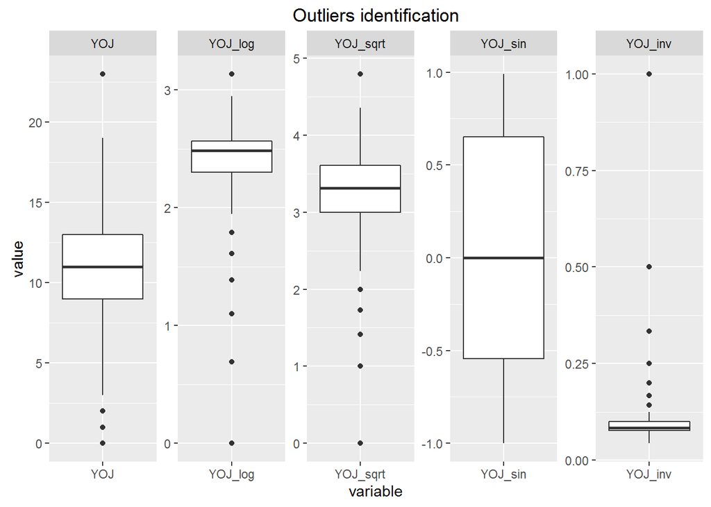

From the above charts we can see that a sin transformation works well for YOJ. Hence, We will create this variable.

### 2.2.2 Missing Values treatment

As we have seen in the data exploration phase, we can do with removing the rows that contain missing values. We now do this removal of rows with missing information:

### 2.2.3 Adding New Variables

In this section, we generate some additional variables that we feel will help the correlations. The following were some of the observations we made during the data exploration phase for TARGET_FLAG  
CAR_TYPE - If you drive Minivans and Panel Trucks you have lesser chance of being in a crash as against Pickups, Sports, SUVs and Vans. Since the distiction is clear, we believe that binning this variable accordingly will help strengthen the correlation. Accordingly, we will bin this variable as below:  
CAR_TYPE_FLAG_BIN :  
- 1 : if CAR_TYPE is Minivans or Panel Trucks  
- 0 : if CAR_TYPE is Pickups, Sports, SUVs or Vans

EDUCATION - If you have only a high school education then you are more likely to crash than if you have a Bachelors, Masters or a Phd. Again binning this variable will strengthen the correlation:  
EDUCATION_FLAG_BIN :  
- 0 : if EDUCATION is High School  
- 1 : if EDUCATION is Bachelors, Masters or Phd  
JOB - If you are a Student, Homemaker, or in a Blue Collar or Clerical job, you are more likely to be in a crash against Doctor, Lawyer, Manager or professional. Again binning this variable will strengthen the correlation:  
JOB_TYPE_FLAG_BIN :  
- 1 : if JOB_TYPE is Student, Homemaker, or in a Blue Collar or Clerical  
- 0 : if JOB_TYPE is Doctor, Lawyer, Manager or professional

## 2.3 Build Models

### 2.3.1 Prepare TRAIN and VALID datasets

However, prior to that, we hold out a subset of data as a validation dataset to check model performance. This will be useful when we select a model.

```r
smp_size <- floor(0.80 * nrow(insure_train_full))

## set the seed to make your partition reproductible
set.seed(123)

train_index <- sample(seq_len(nrow(insure_train_full)), size = smp_size)

DS_TARGET_FLAG_TRAIN<- insure_train_full[train_index, ]
DS_TARGET_FLAG_VALID <- insure_train_full[-train_index, ]
```

This model, we will be using original variables; however using step function (backward process) instead of GLM.

## 2.5 Prediction Using Evaluation Data

### 2.5.1 Tranformation of Evaluation Data

### 2.5.2 Predict Using Selected Model

### 2.5.3 Model Output

# 3 Linear Regression for TARGET_AMT

In this section we will use Linear regression to model the TARGET_AMT. We will first start with the Data Exploration.

## 3.1 Data Exploration Analysis

In this analysis, we will be using only those records where the TARGET-FLAG is 1. This indicates that the vehicle crashed. In such a scenario, we will be modeling the cost of repair using Linear Regression.  
First, lets create the required data set for the “Crashed” data from the existing “clean” full data and look at the structure of the resulting dataset.  
We will remove from the new “crashed” dataset all those variables that were created specifically for predicting TARGET_FLAG. We willbe creating these variables separately for predicting TARGET_AMT.

```
## 'data.frame':    1774 obs. of  46 variables:
##  $ TARGET_AMT                    : num  2946 2501 6077 2920 6857 ...
##  $ KIDSDRIV                      : int  0 0 0 0 0 0 0 0 0 1 ...
##  $ AGE                           : int  34 34 53 45 28 43 32 40 44 45 ...
##  $ HOMEKIDS                      : int  1 0 0 0 1 0 1 0 2 1 ...
##  $ YOJ                           : int  12 10 14 0 13 13 9 11 15 14 ...
##  $ INCOME                        : num  746 4765 5614 2 3436 ...
##  $ HOME_VAL                      : num  2 2 2 82 1350 ...
##  $ TRAVTIME                      : int  46 34 15 48 29 52 26 20 37 50 ...
##  $ BLUEBOOK                      : num  746 135 831 2408 2665 ...
##  $ TIF                           : int  1 1 1 1 6 1 1 4 1 6 ...
##  $ OLDCLAIM                      : num  1 1 1 1 2703 ...
##  $ CLM_FREQ                      : int  0 0 0 0 2 0 0 1 1 2 ...
##  $ MVR_PTS                       : int  0 0 0 3 0 3 0 13 1 0 ...
##  $ CAR_AGE                       : int  7 1 11 5 1 1 1 6 1 13 ...
```

[output cut: 32 more lines]

We notice that the dependent variable here is TARGET_AMT. Apart from the dependent variables, we have 45 independent or predictor variables.  
Also, since we created this dataset from the “Clean” full dataset, we already have taken care of missing values, Outliers etc.  
However, we may need to look into the correlations again since we have a new target variable to correlate against.

### 3.1.1 Data Summary and Correlation Analysis

Now we will produce the correlation table between the independent variables and the dependent variable - TARGET_AMT  
Table: Correlation between TARGET_AMT and predictor variables

|  | Correlation_TARGET_AMT |
| --- | --- |
| TARGET_AMT | 1.0000000 |
| CAR_TYPE_Panel.Truck | 0.0515286 |
| JOB_Professional | 0.0506951 |
| MSTATUS_No | 0.0474827 |
| CAR_TYPE_Van | 0.0448662 |
| SEX_M | 0.0370831 |
| REVOKED_No | 0.0367937 |
| CAR_USE_Commercial | 0.0352950 |
| JOB_Blue.Collar | 0.0339654 |
| MVR_PTS | 0.0332985 |
| INCOME | 0.0275846 |
| YOJ | 0.0275746 |
| PARENT1_Yes | 0.0178348 |
| EDUCATION_Bachelors | 0.0165505 |
| AGE | 0.0160125 |
| EDUCATION_PhD | 0.0148220 |
| RED_CAR_yes | 0.0137540 |
| URBANICITY_Highly.Urban..Urban | 0.0040461 |
| JOB_Lawyer | 0.0035499 |
| CAR_TYPE_Minivan | -0.0026630 |
| URBANICITY_Highly.Rural..Rural | -0.0040461 |
| EDUCATION_Masters | -0.0063514 |
| TRAVTIME | -0.0065361 |
| CAR_TYPE_Sports.Car | -0.0069038 |
| HOMEKIDS | -0.0070844 |
| TIF | -0.0100936 |
| JOB_Doctor | -0.0113055 |
| KIDSDRIV | -0.0135455 |
| RED_CAR_no | -0.0137540 |
| EDUCATION_High.School | -0.0165976 |
| PARENT1_No | -0.0178348 |
| BLUEBOOK | -0.0191492 |
| HOME_VAL | -0.0194683 |
| CAR_TYPE_Pickup | -0.0206986 |
| JOB_Home.Maker | -0.0214662 |
| CAR_AGE | -0.0219861 |
| JOB_Clerical | -0.0229578 |
| JOB_Manager | -0.0268815 |
| OLDCLAIM | -0.0269040 |
| CAR_TYPE_SUV | -0.0270552 |
| CLM_FREQ | -0.0286511 |
| JOB_Student | -0.0309804 |
| CAR_USE_Private | -0.0352950 |
| REVOKED_Yes | -0.0367937 |
| SEX_F | -0.0370831 |
| MSTATUS_Yes | -0.0474827 |

The above table suggests that none of the variables seem to have a very strong correlation with TARGET_AMT.  
However, CAR_TYPE_Panel.Truck, JOB_Professional, MSTATUS_No, CAR_TYPE_Van, SEX_M, REVOKED_No, CAR_USE_Commercial, JOB_Blue.Collar, MVR_PTS, INCOME, YOJ, PARENT1_Yes, EDUCATION_Bachelors, AGE, EDUCATION_PhD, RED_CAR_yes, URBANICITY_Highly.Urban..Urban, JOB_Lawyer have a positive correlation.  
Similarly, CAR_TYPE_Minivan, URBANICITY_Highly.Rural..Rural, EDUCATION_Masters, TRAVTIME, CAR_TYPE_Sports.Car, HOMEKIDS, TIF, JOB_Doctor, KIDSDRIV, RED_CAR_no, EDUCATION_High.School, PARENT1_No, BLUEBOOK, HOME_VAL, CAR_TYPE_Pickup, JOB_Home.Maker, CAR_AGE, JOB_Clerical, JOB_Manager, OLDCLAIM, CAR_TYPE_SUV, CLM_FREQ, JOB_Student, CAR_USE_Private, REVOKED_Yes, SEX_F, MSTATUS_Yes have a negative correlation.  
Lets now see how values in some of the variable affects the correlation:

CAR_TYPE - If you drive Vans or Panel Trucks your cost of repair seems to increase as against Minivan, Pickup, Sports.Car, SUV. Since the distiction is clear, we believe that binning this variable accordingly will help strengthen the correlation.  
EDUCATION - If you have only a high school education then your cost of repair is less compared to a Bachelors, Masters or a Phd. Again binning this variable will strengthen the correlation.  
JOB - If you are a Lawyer, Professional or in a Blue Collar job, you spend more on repairs as compared to a Doctor, Manager, Home Maker, Student, or Clerical job. Again binning this variable will strengthen the correlation.  
We will carry out the above transformations in the Data Preparation phase.

### 3.1.2 Missing Values

To reiterate, since we started with a “clean” dataset, the missing values have already been handled. Lets take a quick look to confirm.  
Table: Missing Values

[output not shown]

### 3.1.3 Outliers identification

In this sub-section, we will look at the boxplots and determine the outliers in variables and decide on whether to act on the outliers.  
We will do the outliers only on the numeric variables.  
Below are the plots:

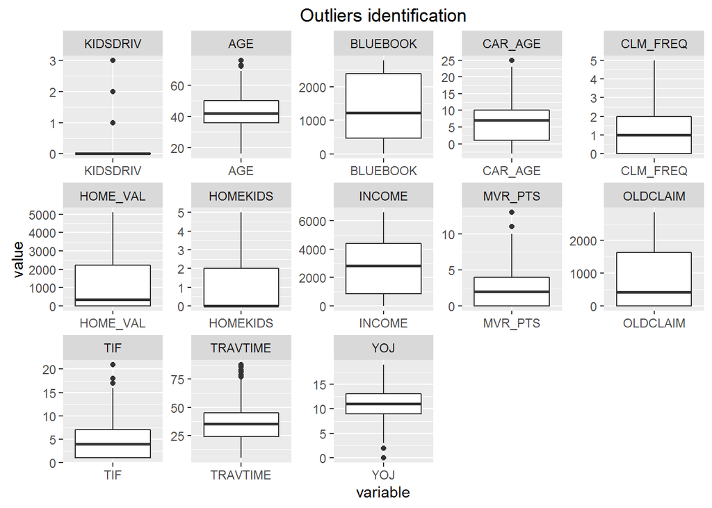

From the “Outliers identification” plot above, we see that we have few outliers that we need to treat.  
We see that: KIDSDRIV, AGE, CAR_AGE, MVR_PTS, TIF, TRAVTIME, YOJ need to be treated when we do the data preparation for modeling the TARGET_AMT.

## 3.2 Data Preparation

Now that we have completed the data exploration / analysis, we will be transforming the data for use in analysis and modeling.  
We will be following the below steps as guidelines:  
- Outliers treatment  
- Missing values treatment  
- Adding New Variables

### 3.2.1 Outliers treatment

In this sub-section, we will check different transformations for each of the variables - KIDSDRIV, AGE, CAR_AGE, MVR_PTS, TIF, TRAVTIME and YOJ - and create the appropriate outlier-handled / transformed variables.

**Transformations for KIDSDRV**

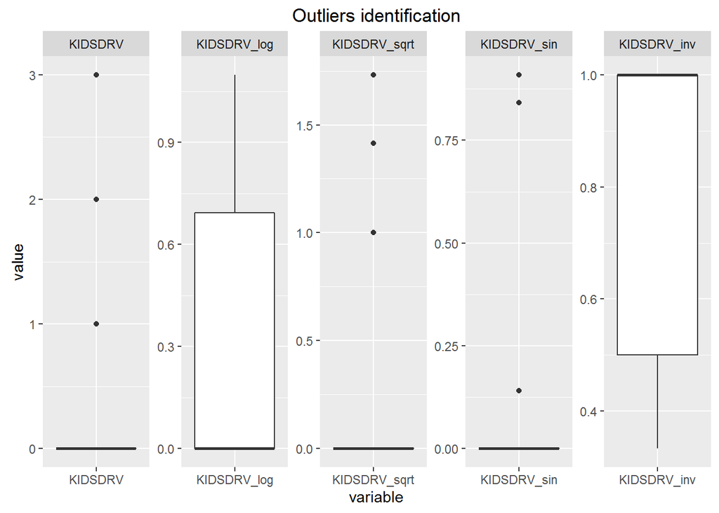

From the above charts we can see that a log or an inverse transformation works well for KIDSDRV. Hence, We create both these variables.

**Transformations for AGE**

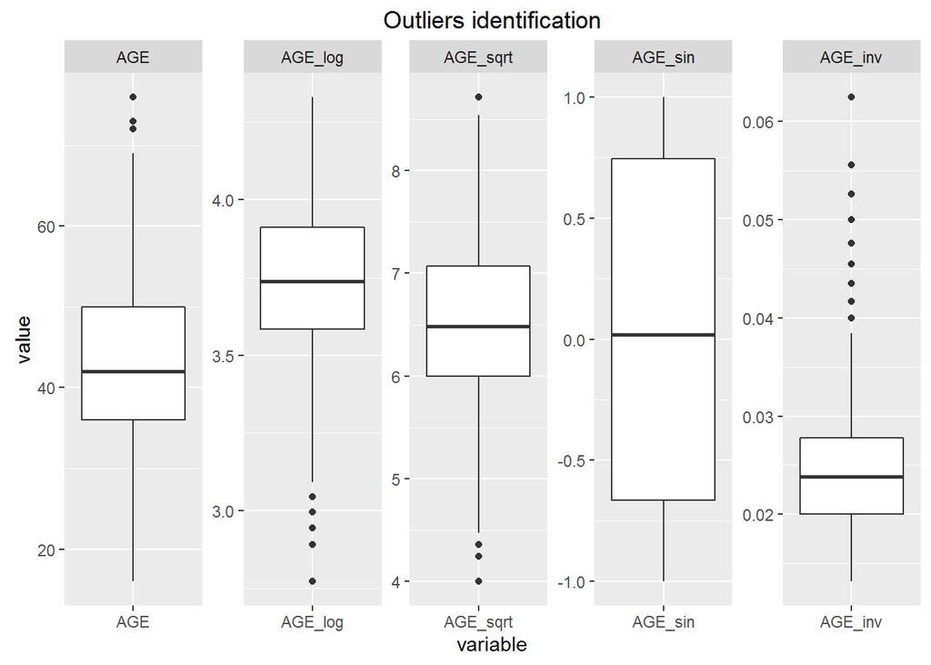

From the above charts we can see that a sin transformation works well for AGE. We will create this variable.

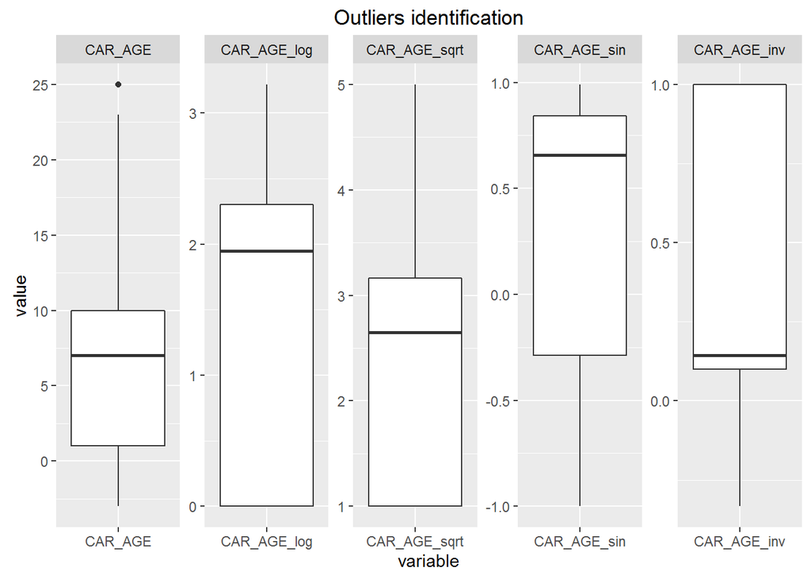

From the above charts we can see that all the transformations address the outliers. However, the log and inverse transformation seem to do a better job of maintaining the central tendancy. So We just use the log and inverse transformation for CAR_AGE.

**Transformations for MVR_PTS**

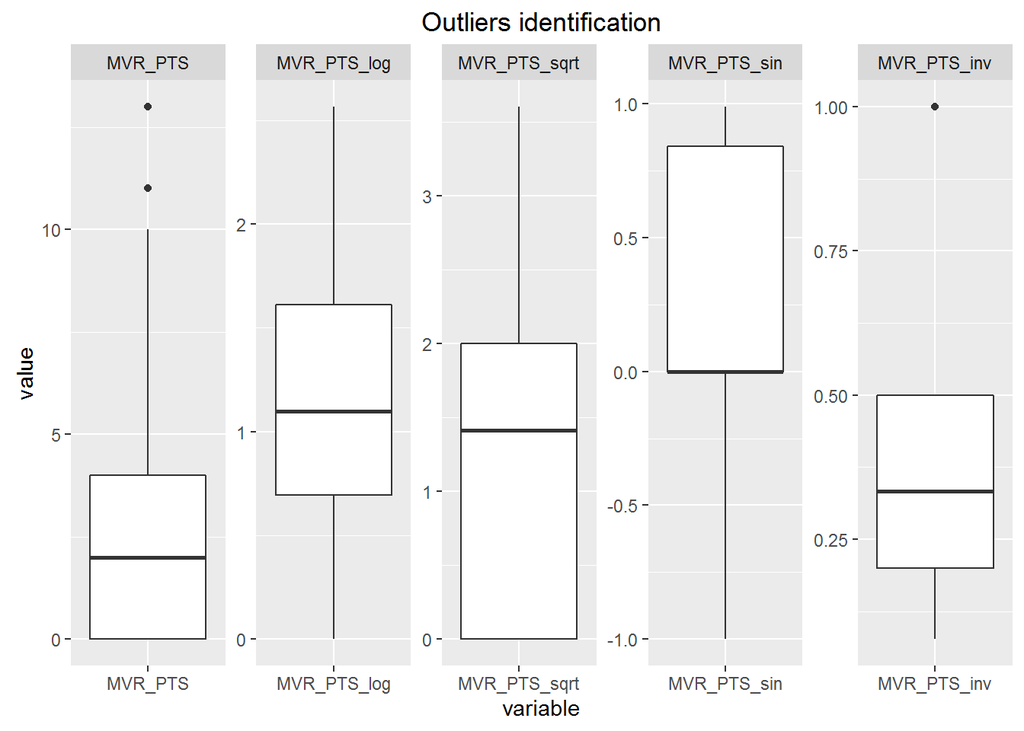

From the above charts we can see that a log, sqrt or a sin transformation works better for MVR_PTS. Hence, We will create these variables.

**Transformations for TIF**

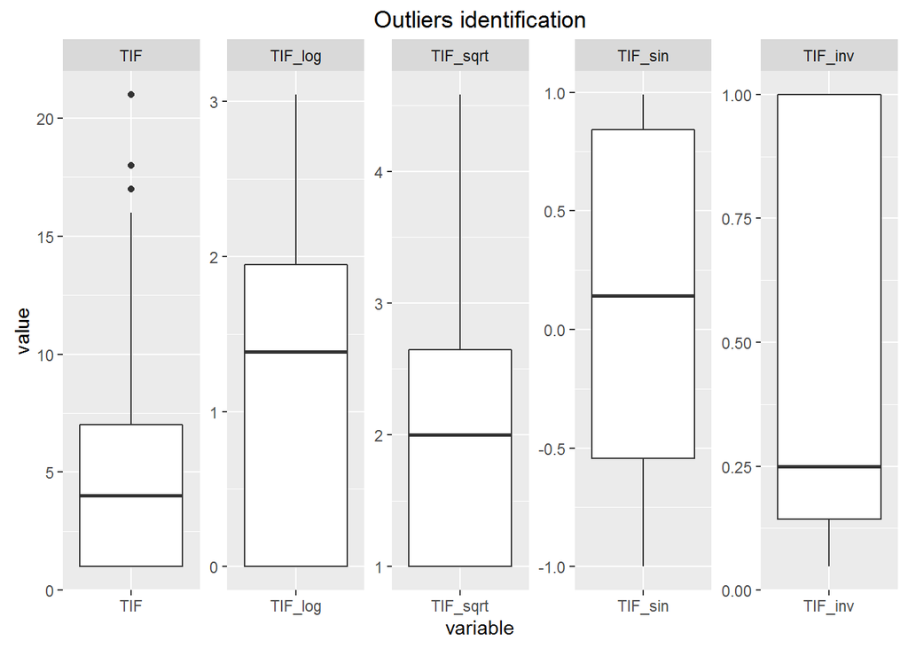

From the above charts we can see that a log, sqrt, sin or an inverse transformation works well for TIF. Hence, We will create these variables.

**Transformations for TRAVTIME**

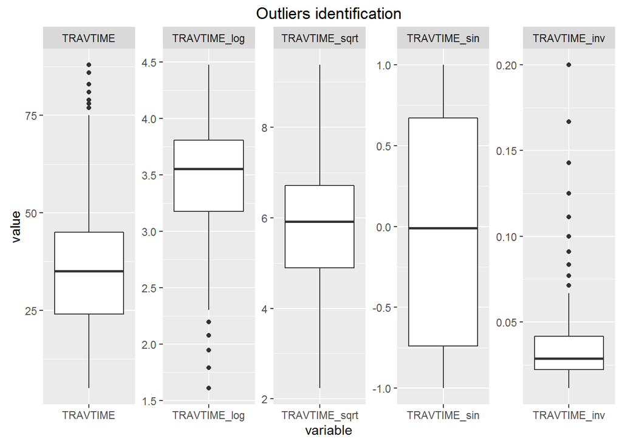

From the above charts we can see that a sqrt and sin transformation works well for TRAVTIME. Hence, We will create these variables.

**Transformations for YOJ**

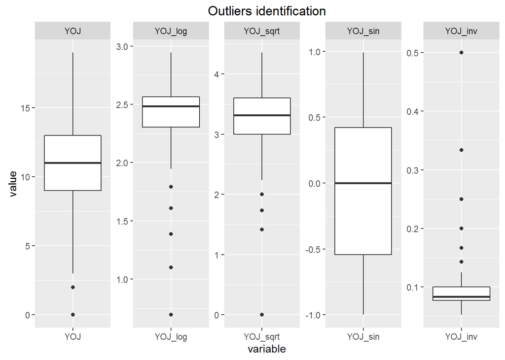

From the above charts we can see that a sin transformation works well for YOJ. Hence, We will create this variable.

### 3.2.2 Adding New Variables

In this section, we generate some additional variables that we feel will help the correlations. The following were some of the observations we made during the data exploration phase for TARGET_AMT.  
The following were some of the observations we made during the data exploration phase for TARGET_AMT

CAR_TYPE - If you drive Vans or Panel Trucks your cost of repair seems to increase as against Minivan, Pickup, Sports.Car, SUV. Since the distiction is clear, we believe that binning this variable accordingly will help strengthen the correlation.

Accordingly, we will bin these variables as below:  
CAR_TYPE_AMT_BIN :  
- 1 : if CAR_TYPE is Vans or Panel Trucks  
- 0 : if CAR_TYPE is Pickups, Sports, SUVs or Minivans

```r
insure_train_crash$CAR_TYPE_AMT_BIN <- ifelse(insure_train_crash$CAR_TYPE_Van | insure_train_crash$CAR_TYPE_Panel.Truck, 1, 0)
```

EDUCATION - If you have only a high school education then your cost of repair is less compared to a Bachelors, Masters or a Phd. Again binning this variable will strengthen the correlation.  
Accordingly, we will bin these variables as below:  
EDUCATION_AMT_BIN :  
- 1 : if EDUCATION is High School  
- 0 : if EDUCATION is Bachelors, Masters or Phd

```r
insure_train_crash$EDUCATION_AMT_BIN <- ifelse(insure_train_crash$EDUCATION_High.School, 1, 0)
```

JOB - If you are a Lawyer, Professional or in a Blue Collar job, you spend more on repairs as compared to a Doctor, Manager, Home Maker, Student, or Clerical job. Again binning this variable will strengthen the correlation.

Accordingly, we will bin these variables as below:  
JOB_TYPE_AMT_BIN :  
- 1 : if JOB_TYPE is Lawyer, Professional or in a Blue Collar  
- 0 : if JOB_TYPE is Doctor, Manager, Home Maker, Student, or Clerical

```r
insure_train_crash$JOB_TYPE_AMT_BIN <- ifelse(insure_train_crash$JOB_Lawyer |  insure_train_crash$JOB_Professional | insure_train_crash$JOB_Blue.Collar, 1, 0)
```

## 3.5 Prediction Using Evaluation Data

### 3.5.1 Tranformation of Evaluation Data

### 3.5.2 Independent Prediction Using Selected Model

### 3.5.3 Dependent Prediction Using Selected Model

# 4 Conclusion